# Lab6

Luna Herschenfeld-Catalán

2023-03-01

## Case Study: Eel Distribution Modeling

This week’s lab follows a project modeling the eel species Anguilla australis described by Elith et al. (2008). There are two data sets for this lab. You’ll use one for training and evaluating your model, and you’ll use your model to make predictions predictions on the other. Then you’ll compare your model’s performance to the model used by Elith et al.

## Data

Grab the training data sets (eel.model.data.csv, eel.eval.data.csv) from github here: https://github.com/MaRo406/eds-232-machine-learning/blob/main/data

```r
library(spotifyr) #API interaction
library(tidyverse)
library(tidymodels)
library(parsnip)

set.seed(136)
knitr::opts_chunk$set(echo = TRUE, message = FALSE, warning = FALSE)
```

### Split and Resample

Split the model data (eel.model.data.csv) into a training and test set, stratified by outcome score (Angaus). Use 10-fold CV to resample the training set.

```r
eel_model <- read_csv(here::here("labs", "data", "eel.model.data.csv")) %>%
  select(-Site) %>%
  mutate(Angaus = as.factor(Angaus),
         Method = as.factor(Method))

# Split the data
eel_split <- initial_split(eel_model, strata = Angaus)
eel_train <- training(eel_split)
eel_test <- testing(eel_split)

cv_folds = vfold_cv(eel_train, v = 10)
```

### Preprocess

Create a recipe to prepare your data for the XGBoost model

```r
eel_recipe <- recipe(Angaus ~ ., data = eel_train) %>%
  step_dummy(all_nominal_predictors()) %>% #create dummy variables from all factors
  step_normalize(all_numeric_predictors()) #normalize all numeric predictors
```

## Tuning XGBoost

### Tune Learning Rate

Following the XGBoost tuning strategy outlined in lecture, first we conduct tuning on just the learning rate parameter:

1. Create a model specification using {xgboost} for the estimation
- Only specify one parameter to tune()

```r
xgb_model <- boost_tree(learn_rate = tune()) %>%
  set_engine("xgboost") %>% # engine for boost trees
  set_mode("classification")

xgb_workflow <- workflow() %>%
  add_model(xgb_model) %>%
  add_recipe(eel_recipe)
```

2. Set up a grid to tune your model by using a range of learning rate parameter values: expand.grid(learn_rate = seq(0.0001, 0.3, length.out = 30))
- Use appropriate metrics argument(s) - Computational efficiency becomes a factor as models get more complex and data get larger. Record the time it takes to run. Do this for each tuning phase you run.You could use {tictoc} or Sys.time().

```r
# Resampling
  #  user  system elapsed
  # 8.587   0.083   8.747
system.time(

  xgb_grid <- tune_grid(
    xgb_workflow, # add workflow
    resamples = cv_folds, # add folds
    grid = expand.grid(learn_rate = seq(0.0001, 0.3,
                                        length.out = 30)),
    metrics = metric_set(roc_auc)
  )
)
```

```
##    user  system elapsed
##   8.405   0.070   8.570
```

3. Show the performance of the best models and the estimates for the learning rate parameter values associated with each.

```r
# look at the metrics for each model
collect_metrics(xgb_grid)
```

```
## # A tibble: 30 × 7
##    learn_rate .metric .estimator  mean     n std_err .config
##         <dbl> <chr>   <chr>      <dbl> <int>   <dbl> <chr>
##  1     0.0001 roc_auc binary     0.786    10  0.0217 Preprocessor1_Model01
##  2     0.0104 roc_auc binary     0.797    10  0.0221 Preprocessor1_Model02
##  3     0.0208 roc_auc binary     0.809    10  0.0209 Preprocessor1_Model03
##  4     0.0311 roc_auc binary     0.821    10  0.0187 Preprocessor1_Model04
##  5     0.0415 roc_auc binary     0.822    10  0.0169 Preprocessor1_Model05
##  6     0.0518 roc_auc binary     0.832    10  0.0178 Preprocessor1_Model06
##  7     0.0621 roc_auc binary     0.834    10  0.0164 Preprocessor1_Model07
##  8     0.0725 roc_auc binary     0.838    10  0.0186 Preprocessor1_Model08
##  9     0.0828 roc_auc binary     0.838    10  0.0202 Preprocessor1_Model09
## 10     0.0932 roc_auc binary     0.838    10  0.0201 Preprocessor1_Model10
## # ℹ 20 more rows
```

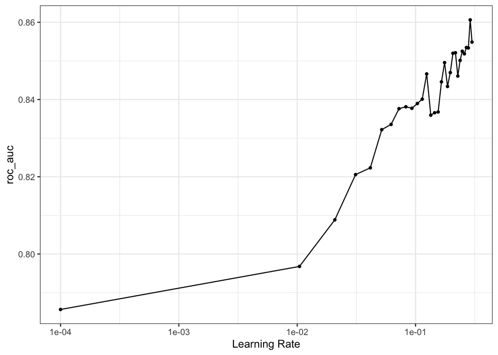

```r
autoplot(xgb_grid) + #plot cv results for parameter tuning
  theme_bw()
```

```r
show_best(xgb_grid, n = 1, metric = "roc_auc")
```

```
## # A tibble: 1 × 7
##   learn_rate .metric .estimator  mean     n std_err .config
##        <dbl> <chr>   <chr>      <dbl> <int>   <dbl> <chr>
## 1      0.290 roc_auc binary     0.861    10  0.0192 Preprocessor1_Model29
```

### Tune Tree Parameters

1. Create a new specification where you set the learning rate (which you already optimized) and tune the tree parameters.

```r
# learning rate: 0.2896586

xgb_model_2 <- boost_tree(learn_rate = 0.2896586,
                          tree_depth = tune(), # depth of tree
                          trees = 3000, # number of trees
                          loss_reduction = tune(),
                          min_n = tune()) %>%  # min number of trees
  set_engine("xgboost") %>% # engine for boost trees
  set_mode("classification")

xgb_workflow_2 <- workflow() %>%
  add_model(xgb_model_2) %>%
  add_recipe(eel_recipe)
```

2. Set up a tuning grid. This time use grid_latin_hypercube() to get a representative sampling of the parameter space
- Figure this out!

```r
#extract_parameter_set_dials(xgb_workflow_2)

# Resampling
  #  user  system elapsed
  # 31.597   0.528  31.932
system.time(

  xgb_grid_2 <- tune_grid(
    xgb_workflow_2, # add workflow
    resamples = cv_folds, # add folds
    grid = grid_latin_hypercube(tree_depth(),
                                min_n(),
                                loss_reduction()),
    metrics = metric_set(roc_auc)
  )
)
```

```
##    user  system elapsed
##  21.290   0.267  21.838
```

3. Show the performance of the best models and the estimates for the tree parameter values associated with each.

```r
# look at the metrics for each model
collect_metrics(xgb_grid_2)
```

```
## # A tibble: 3 × 9
##   min_n tree_depth loss_reduction .metric .estimator  mean     n std_err .config
##   <int>      <int>          <dbl> <chr>   <chr>      <dbl> <int>   <dbl> <chr>
## 1    11         12       5.51e-10 roc_auc binary     0.802    10  0.0188 Prepro…
## 2    31         10       4.63e- 6 roc_auc binary     0.808    10  0.0185 Prepro…
## 3    22          2       2.86e- 1 roc_auc binary     0.827    10  0.0189 Prepro…
```

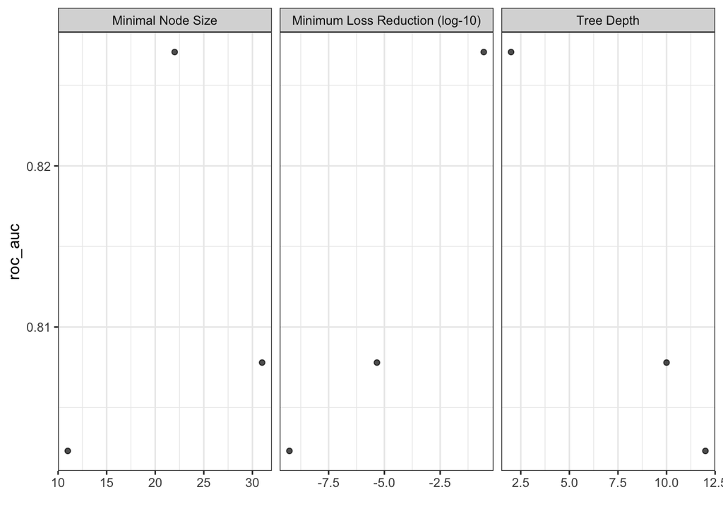

```r
autoplot(xgb_grid_2) + #plot cv results for parameter tuning
  theme_bw()
```

```r
show_best(xgb_grid_2, n = 1, metric = "roc_auc")
```

```
## # A tibble: 1 × 9
##   min_n tree_depth loss_reduction .metric .estimator  mean     n std_err .config
##   <int>      <int>          <dbl> <chr>   <chr>      <dbl> <int>   <dbl> <chr>
## 1    22          2          0.286 roc_auc binary     0.827    10  0.0189 Prepro…
```